# Quantium Virtual Internship — Task 1

## Retail Strategy and Analytics: Análisis exploratorio de datos (EDA) en Python

Este notebook es la traducción a Python del template en R Markdown (`InsideSherpa_Task1_DraftSolutions`).

**Datasets requeridos** :

- `QVI_transaction_data.csv`
- `QVI_purchase_behaviour.csv`

## 0. Cargar librerías

```python
%pip install pandas numpy matplotlib seaborn scipy
```

```python
%pip install openpyxl
```

```python
# pandas: manipulación y análisis de datos tabulares (equivalente a data.table en R)

import pandas as pd

# numpy: operaciones numéricas de soporte (usado internamente por pandas y para cálculos)
import numpy as np

# re: expresiones regulares, para limpiar texto (nombres de producto)
import re

# Counter: para contar frecuencias de palabras de forma sencilla
from collections import Counter

# matplotlib: motor base de gráficos
import matplotlib.pyplot as plt

# seaborn: gráficos estadísticos más elaborados sobre matplotlib (barras agrupadas, etc.)
import seaborn as sns

# scipy.stats: para la prueba de hipótesis (t-test) más adelante
from scipy import stats

# Configuración visual: tamaño de fuente y estilo de fondo de los gráficos
sns.set_theme(style="whitegrid")  # equivalente a theme_bw() + theme_set() en ggplot2
plt.rcParams["figure.figsize"] = (12, 6)  # tamaño por defecto de las figuras
```

```python
import sys

print(sys.executable)
print(sys.version)
```

```
C:\Users\andre\AppData\Local\Microsoft\WindowsApps\PythonSoftwareFoundation.Python.3.11_qbz5n2kfra8p0\python.exe
3.11.9 (tags/v3.11.9:de54cf5, Apr  2 2024, 10:12:12) [MSC v.1938 64 bit (AMD64)]
```

```python
from pathlib import Path

file_path = Path(r"C:\Users\andre\OneDrive\Documentos\M1D@5_777\7_Simulaciones de trabajo\quantium")

print("¿Existe la carpeta?", file_path.exists())
print("¿Es un directorio?", file_path.is_dir())

print("\nContenido:")
for archivo in file_path.iterdir():
    print(archivo.name)
```

```
¿Existe la carpeta? True
¿Es un directorio? True

Contenido:
.git
.venv
InsideSherpa_Task1_DraftSolutions - Template.pdf
Quantium_Task1_EDA_Python.html
Quantium_Task1_EDA_Python.ipynb
Quantium_Task1_EDA_Python.pdf
QVI_data.csv
QVI_purchase_behaviour.csv
QVI_transaction_data.xlsx
```

## 1. Cargar los datasets

```python
# Ruta donde están guardados los archivos CSV; edítala según tu entorno
file_path = r"C:\Users\andre\OneDrive\Documentos\M1D@5_777\7_Simulaciones de trabajo\quantium\\"

# Leemos el archivo de transacciones y lo cargamos como DataFrame de pandas
transaction_data = pd.read_excel(file_path + "QVI_transaction_data.xlsx")

# Leemos el archivo de comportamiento de compra / segmentación de clientes
customer_data = pd.read_csv(file_path + "QVI_purchase_behaviour.csv")
```

## 2. Exploración inicial de `transaction_data`

```python
# .info() muestra tipos de dato por columna, cantidad de nulos y uso de memoria
# (equivalente a str() en R): nos deja ver si DATE está como número en vez de fecha
transaction_data.info()
```

```
<class 'pandas.DataFrame'>
RangeIndex: 264836 entries, 0 to 264835
Data columns (total 8 columns):
 #   Column          Non-Null Count   Dtype
---  ------          --------------   -----
 0   DATE            264836 non-null  int64
 1   STORE_NBR       264836 non-null  int64
 2   LYLTY_CARD_NBR  264836 non-null  int64
 3   TXN_ID          264836 non-null  int64
 4   PROD_NBR        264836 non-null  int64
 5   PROD_NAME       264836 non-null  str
 6   PROD_QTY        264836 non-null  int64
 7   TOT_SALES       264836 non-null  float64
dtypes: float64(1), int64(6), str(1)
memory usage: 16.2 MB
```

```python
# .head() muestra las primeras 5 filas para inspeccionar visualmente el contenido
transaction_data.head()
```

|  | DATE | STORE_NBR | LYLTY_CARD_NBR | TXN_ID | PROD_NBR | PROD_NAME | PROD_QTY | TOT_SALES |
| --- | --- | --- | --- | --- | --- | --- | --- | --- |
| 0 | 43390 | 1 | 1000 | 1 | 5 | Natural Chip Compny SeaSalt175g | 2 | 6.0 |
| 1 | 43599 | 1 | 1307 | 348 | 66 | CCs Nacho Cheese 175g | 3 | 6.3 |
| 2 | 43605 | 1 | 1343 | 383 | 61 | Smiths Crinkle Cut Chips Chicken 170g | 2 | 2.9 |
| 3 | 43329 | 2 | 2373 | 974 | 69 | Smiths Chip Thinly S/Cream&Onion 175g | 5 | 15.0 |
| 4 | 43330 | 2 | 2426 | 1038 | 108 | Kettle Tortilla ChpsHny&Jlpno Chili 150g | 3 | 13.8 |

```python
# .describe() calcula estadísticas descriptivas (media, min, max, percentiles)
# de las columnas numéricas; ayuda a detectar outliers desde ya
transaction_data.describe()
```

|  | DATE | STORE_NBR | LYLTY_CARD_NBR | TXN_ID | PROD_NBR | PROD_QTY | TOT_SALES |
| --- | --- | --- | --- | --- | --- | --- | --- |
| count | 264836.000000 | 264836.00000 | 2.648360e+05 | 2.648360e+05 | 264836.000000 | 264836.000000 | 264836.000000 |
| mean | 43464.036260 | 135.08011 | 1.355495e+05 | 1.351583e+05 | 56.583157 | 1.907309 | 7.304200 |
| std | 105.389282 | 76.78418 | 8.057998e+04 | 7.813303e+04 | 32.826638 | 0.643654 | 3.083226 |
| min | 43282.000000 | 1.00000 | 1.000000e+03 | 1.000000e+00 | 1.000000 | 1.000000 | 1.500000 |
| 25% | 43373.000000 | 70.00000 | 7.002100e+04 | 6.760150e+04 | 28.000000 | 2.000000 | 5.400000 |
| 50% | 43464.000000 | 130.00000 | 1.303575e+05 | 1.351375e+05 | 56.000000 | 2.000000 | 7.400000 |
| 75% | 43555.000000 | 203.00000 | 2.030942e+05 | 2.027012e+05 | 85.000000 | 2.000000 | 9.200000 |
| max | 43646.000000 | 272.00000 | 2.373711e+06 | 2.415841e+06 | 114.000000 | 200.000000 | 650.000000 |

## 3. Convertir la columna `DATE` a formato fecha

La columna `DATE` viene como un número entero (formato serial de Excel/CSV), donde el día 0 corresponde al 30 de diciembre de 1899. Hay que convertirla a un tipo de dato `datetime` para poder graficarla y agruparla correctamente.

```python
# unit="D" indica que el número representa una cantidad de días
# origin="1899-12-30" es el punto de partida que usan Excel y CSV para fechas seriales
transaction_data["DATE"] = pd.to_datetime(
    transaction_data["DATE"], unit="D", origin="1899-12-30"
)

# Verificamos que la conversión fue exitosa mostrando el nuevo tipo de dato
transaction_data["DATE"].head()
```

```
0   2018-10-17
1   2019-05-14
2   2019-05-20
3   2018-08-17
4   2018-08-18
Name: DATE, dtype: datetime64[s]
```

## 4. Examinar `PROD_NAME`

Queremos confirmar que todos los productos son efectivamente "papas fritas" (chips) y no otra categoría que se haya colado en el dataset (por ejemplo, salsas).

```python
# .value_counts() cuenta cuántas veces aparece cada nombre de producto distinto
# .head(20) limita la salida a los 20 productos más frecuentes, para no saturar la vista
transaction_data["PROD_NAME"].value_counts().head(20)
```

```
PROD_NAME
Kettle Mozzarella   Basil & Pesto 175g      3304
Kettle Tortilla ChpsHny&Jlpno Chili 150g    3296
Cobs Popd Swt/Chlli &Sr/Cream Chips 110g    3269
Tyrrells Crisps     Ched & Chives 165g      3268
Cobs Popd Sea Salt  Chips 110g              3265
Kettle 135g Swt Pot Sea Salt                3257
Tostitos Splash Of  Lime 175g               3252
Infuzions Thai SweetChili PotatoMix 110g    3242
Smiths Crnkle Chip  Orgnl Big Bag 380g      3233
Thins Potato Chips  Hot & Spicy 175g        3229
Kettle Sensations   Camembert & Fig 150g    3219
Doritos Corn Chips  Cheese Supreme 170g     3217
Pringles Barbeque   134g                    3210
Doritos Corn Chip Mexican Jalapeno 150g     3204
Kettle Sweet Chilli And Sour Cream 175g     3200
Smiths Crinkle Chips Salt & Vinegar 330g    3197
Thins Chips Light&  Tangy 175g              3188
Dorito Corn Chp     Supreme 380g            3185
Pringles Sweet&Spcy BBQ 134g                3177
Infuzions BBQ Rib   Prawn Crackers 110g     3174
Name: count, dtype: int64
```

```python
# Unimos todos los nombres de producto ÚNICOS en un solo string separado por espacios
# .unique() evita contar la misma palabra muchas veces solo porque el producto se repite
all_names = " ".join(transaction_data["PROD_NAME"].unique())

# .split() separa el string gigante en una lista de palabras individuales (por espacio)
words = all_names.split()

# Mostramos cuántas palabras en total se extrajeron, solo para verificar
len(words)
```

```
589
```

```python
# re.sub(r"[^A-Za-z]", "", w) elimina cualquier caracter que NO sea una letra
# (quita dígitos como "175g" -> "g", símbolos como "&", etc.)
clean_words = [re.sub(r"[^A-Za-z]", "", w) for w in words]

# Filtramos los strings que quedaron vacíos después de la limpieza (por ejemplo "175g" -> "")
clean_words = [w for w in clean_words if w != ""]

# Counter cuenta cuántas veces aparece cada palabra limpia y .most_common() las ordena
# de mayor a menor frecuencia
word_freq = Counter(clean_words).most_common()

# Convertimos el resultado a un DataFrame para visualizarlo como tabla ordenada
word_freq_df = pd.DataFrame(word_freq, columns=["word", "count"])

# Mostramos las 20 palabras más frecuentes: aquí es donde detectaríamos "Salsa"
# si hubiera productos que no son chips
word_freq_df.head(20)
```

|  | word | count |
| --- | --- | --- |
| 0 | g | 105 |
| 1 | Chips | 21 |
| 2 | Smiths | 16 |
| 3 | Crinkle | 14 |
| 4 | Cut | 14 |
| 5 | Kettle | 13 |
| 6 | Cheese | 12 |
| 7 | Salt | 12 |
| 8 | Original | 10 |
| 9 | Chip | 9 |
| 10 | Salsa | 9 |
| 11 | Doritos | 9 |
| 12 | Corn | 8 |
| 13 | Pringles | 8 |
| 14 | RRD | 8 |
| 15 | Chicken | 7 |
| 16 | WW | 7 |
| 17 | Chilli | 6 |
| 18 | Sour | 6 |
| 19 | Sea | 6 |

## 5. Eliminar productos de salsa (no pertenecen a la categoría chips)

```python
# .str.lower() convierte el nombre del producto a minúsculas para comparar sin
# importar mayúsculas/minúsculas
# .str.contains("salsa") devuelve True/False si la palabra "salsa" aparece en el nombre
is_salsa = transaction_data["PROD_NAME"].str.lower().str.contains("salsa")

# El operador ~ invierte la máscara booleana (True se vuelve False y viceversa)
# Así nos quedamos solo con las filas donde is_salsa es False (no son salsa)
transaction_data = transaction_data[~is_salsa]

# Confirmamos cuántas filas quedaron después de filtrar
transaction_data.shape
```

```
(246742, 8)
```

## 6. Resumen estadístico y detección de outliers

Revisamos nulos y valores extremos en las columnas clave antes de seguir.

```python
# .isna() marca True donde hay valores nulos; .sum() cuenta cuántos hay por columna
# Si todos los valores son 0, significa que no hay datos faltantes
transaction_data.isna().sum()
```

```
DATE              0
STORE_NBR         0
LYLTY_CARD_NBR    0
TXN_ID            0
PROD_NBR          0
PROD_NAME         0
PROD_QTY          0
TOT_SALES         0
dtype: int64
```

```python
# Volvemos a correr describe() ya con los datos filtrados, para ver si PROD_QTY
# (cantidad de productos por transacción) tiene un máximo sospechosamente alto
transaction_data.describe()
```

|  | DATE | STORE_NBR | LYLTY_CARD_NBR | TXN_ID | PROD_NBR | PROD_QTY | TOT_SALES |
| --- | --- | --- | --- | --- | --- | --- | --- |
| count | 246742 | 246742.000000 | 2.467420e+05 | 2.467420e+05 | 246742.000000 | 246742.000000 | 246742.000000 |
| mean | 2018-12-30 01:19:01 | 135.051098 | 1.355310e+05 | 1.351311e+05 | 56.351789 | 1.908062 | 7.321322 |
| min | 2018-07-01 00:00:00 | 1.000000 | 1.000000e+03 | 1.000000e+00 | 1.000000 | 1.000000 | 1.700000 |
| 25% | 2018-09-30 00:00:00 | 70.000000 | 7.001500e+04 | 6.756925e+04 | 26.000000 | 2.000000 | 5.800000 |
| 50% | 2018-12-30 00:00:00 | 130.000000 | 1.303670e+05 | 1.351830e+05 | 53.000000 | 2.000000 | 7.400000 |
| 75% | 2019-03-31 00:00:00 | 203.000000 | 2.030840e+05 | 2.026538e+05 | 87.000000 | 2.000000 | 8.800000 |
| max | 2019-06-30 00:00:00 | 272.000000 | 2.373711e+06 | 2.415841e+06 | 114.000000 | 200.000000 | 650.000000 |
| std | NaN | 76.787096 | 8.071528e+04 | 7.814772e+04 | 33.695428 | 0.659831 | 3.077828 |

```python
# Filtramos las transacciones donde se compraron exactamente 200 unidades,
# el valor atípico (outlier) que detectamos en el describe() anterior
outlier_transactions = transaction_data[transaction_data["PROD_QTY"] == 200]

# Mostramos esas transacciones para inspeccionarlas manualmente
outlier_transactions
```

|  | DATE | STORE_NBR | LYLTY_CARD_NBR | TXN_ID | PROD_NBR | PROD_NAME | PROD_QTY | TOT_SALES |
| --- | --- | --- | --- | --- | --- | --- | --- | --- |
| 69762 | 2018-08-19 | 226 | 226000 | 226201 | 4 | Dorito Corn Chp Supreme 380g | 200 | 650.0 |
| 69763 | 2019-05-20 | 226 | 226000 | 226210 | 4 | Dorito Corn Chp Supreme 380g | 200 | 650.0 |

```python
# Extraemos el/los número(s) de tarjeta de lealtad (LYLTY_CARD_NBR) involucrados
# en la transacción atípica, para revisar el historial completo de ese cliente
loyalty_card_outlier = outlier_transactions["LYLTY_CARD_NBR"].unique()

# .isin() filtra todas las filas donde el número de tarjeta esté en la lista anterior
# Esto nos muestra TODAS las compras hechas por ese cliente en el período analizado
transaction_data[transaction_data["LYLTY_CARD_NBR"].isin(loyalty_card_outlier)]
```

|  | DATE | STORE_NBR | LYLTY_CARD_NBR | TXN_ID | PROD_NBR | PROD_NAME | PROD_QTY | TOT_SALES |
| --- | --- | --- | --- | --- | --- | --- | --- | --- |
| 69762 | 2018-08-19 | 226 | 226000 | 226201 | 4 | Dorito Corn Chp Supreme 380g | 200 | 650.0 |
| 69763 | 2019-05-20 | 226 | 226000 | 226210 | 4 | Dorito Corn Chp Supreme 380g | 200 | 650.0 |

```python
# Como el cliente solo tiene esas dos transacciones extremas en todo el año,
# probablemente no es un consumidor minorista normal (podría ser compra comercial)
# Lo excluimos del análisis usando ~ (negación) sobre isin()
transaction_data = transaction_data[
    ~transaction_data["LYLTY_CARD_NBR"].isin(loyalty_card_outlier)
]

# Volvemos a describir los datos para confirmar que el outlier ya no aparece
transaction_data.describe()
```

|  | DATE | STORE_NBR | LYLTY_CARD_NBR | TXN_ID | PROD_NBR | PROD_QTY | TOT_SALES |
| --- | --- | --- | --- | --- | --- | --- | --- |
| count | 246740 | 246740.000000 | 2.467400e+05 | 2.467400e+05 | 246740.000000 | 246740.000000 | 246740.000000 |
| mean | 2018-12-30 01:18:58 | 135.050361 | 1.355303e+05 | 1.351304e+05 | 56.352213 | 1.906456 | 7.316113 |
| min | 2018-07-01 00:00:00 | 1.000000 | 1.000000e+03 | 1.000000e+00 | 1.000000 | 1.000000 | 1.700000 |
| 25% | 2018-09-30 00:00:00 | 70.000000 | 7.001500e+04 | 6.756875e+04 | 26.000000 | 2.000000 | 5.800000 |
| 50% | 2018-12-30 00:00:00 | 130.000000 | 1.303670e+05 | 1.351815e+05 | 53.000000 | 2.000000 | 7.400000 |
| 75% | 2019-03-31 00:00:00 | 203.000000 | 2.030832e+05 | 2.026522e+05 | 87.000000 | 2.000000 | 8.800000 |
| max | 2019-06-30 00:00:00 | 272.000000 | 2.373711e+06 | 2.415841e+06 | 114.000000 | 5.000000 | 29.500000 |
| std | NaN | 76.786971 | 8.071520e+04 | 7.814760e+04 | 33.695235 | 0.342499 | 2.474897 |

## 7. Conteo de transacciones por fecha (buscar días faltantes)

El dataset debería cubrir 365 días (1 jul 2018 - 30 jun 2019). Si el conteo de fechas únicas da menos de 365, significa que falta al menos un día de datos.

```python
# .groupby("DATE") agrupa las filas por fecha
# .size() cuenta cuántas transacciones (filas) hay en cada fecha
# .reset_index(name="N") convierte el resultado agrupado de nuevo en un DataFrame,
# nombrando la columna de conteo como "N"
tx_by_day = transaction_data.groupby("DATE").size().reset_index(name="N")

# len() nos dice cuántas fechas distintas hay en total; si es 364 en vez de 365,
# confirma que falta un día
len(tx_by_day)
```

```
364
```

```python
# Creamos un rango de fechas completo, día por día, cubriendo TODO el período
# esperado (1 jul 2018 a 30 jun 2019), sin importar si hay datos ese día o no
full_dates = pd.DataFrame({
    "DATE": pd.date_range(start="2018-07-01", end="2019-06-30", freq="D")
})

# Unimos (left join) el rango completo de fechas con el conteo real de transacciones
# how="left" asegura que se mantengan TODAS las fechas del rango, aunque no tengan datos
tx_by_day = full_dates.merge(tx_by_day, on="DATE", how="left")

# Los días sin transacciones quedan como NaN después del merge; los reemplazamos por 0
tx_by_day["N"] = tx_by_day["N"].fillna(0)

# Mostramos las primeras filas para confirmar que ahora sí hay 365 fechas
tx_by_day.shape
```

```
(365, 2)
```

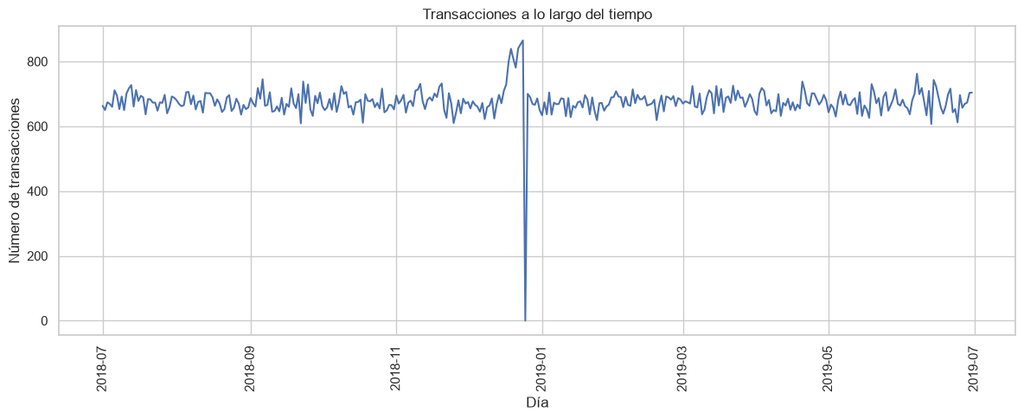

```python
# Creamos la figura y los ejes con un tamaño específico (ancho=12, alto=5 pulgadas)
fig, ax = plt.subplots(figsize=(12, 5))

# Graficamos una línea con el eje X = fecha y el eje Y = número de transacciones
ax.plot(tx_by_day["DATE"], tx_by_day["N"])

# Etiquetas de los ejes, en español, para que el gráfico sea autoexplicativo
ax.set_xlabel("Día")
ax.set_ylabel("Número de transacciones")
ax.set_title("Transacciones a lo largo del tiempo")

# Rotamos las etiquetas del eje X 90 grados para que no se superpongan
plt.xticks(rotation=90)

# Ajusta automáticamente los márgenes para que no se corten las etiquetas
plt.tight_layout()

# Muestra el gráfico en el notebook
plt.show()
```

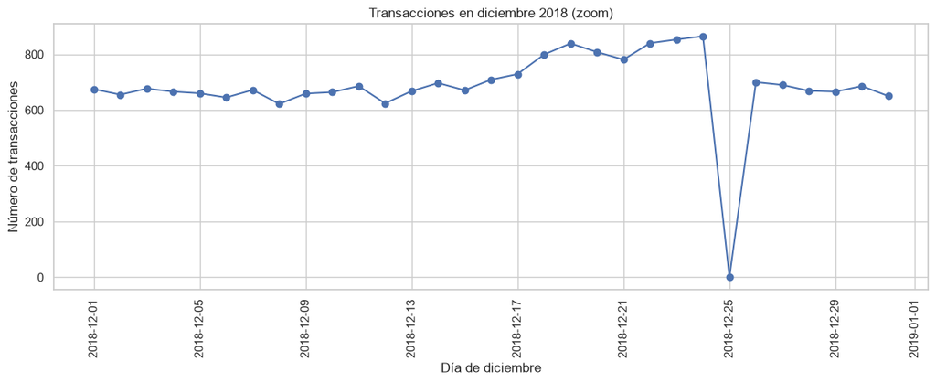

```python
# Filtramos tx_by_day para quedarnos solo con el mes de diciembre de 2018,
# donde vimos un pico y una caída en el gráfico anterior
december = tx_by_day[
    (tx_by_day["DATE"] >= "2018-12-01") & (tx_by_day["DATE"] <= "2018-12-31")
]

# Creamos el gráfico de línea con marcadores en cada punto (marker="o") para ver
# claramente cada día individual de diciembre
fig, ax = plt.subplots(figsize=(12, 5))
ax.plot(december["DATE"], december["N"], marker="o")

ax.set_xlabel("Día de diciembre")
ax.set_ylabel("Número de transacciones")
ax.set_title("Transacciones en diciembre 2018 (zoom)")

plt.xticks(rotation=90)
plt.tight_layout()
plt.show()

# Se espera ver un aumento previo a Navidad y una caída a 0 el 25 de diciembre
# (día en que las tiendas están cerradas)
```

## 8. Crear la variable `PACK_SIZE`

Extraemos el tamaño del empaque (en gramos) directamente del texto en `PROD_NAME`, ya que el número siempre aparece junto a la "g" de gramos (ej. "175g").

```python
# .str.extract(r"(\d+)") busca el primer grupo de uno o más dígitos consecutivos
# en cada nombre de producto y lo devuelve como texto
# .astype(int) convierte ese texto extraído en un número entero
transaction_data["PACK_SIZE"] = (
    transaction_data["PROD_NAME"].str.extract(r"(\d+)").astype(int)
)

# .value_counts() cuenta cuántas transacciones hay por cada tamaño de empaque
# .sort_index() ordena el resultado de menor a mayor tamaño (no por frecuencia)
transaction_data["PACK_SIZE"].value_counts().sort_index()
```

```
PACK_SIZE
70      1507
90      3008
110    22387
125     1454
134    25102
135     3257
150    40203
160     2970
165    15297
170    19983
175    66390
180     1468
190     2995
200     4473
210     6272
220     1564
250     3169
270     6285
330    12540
380     6416
Name: count, dtype: int64
```

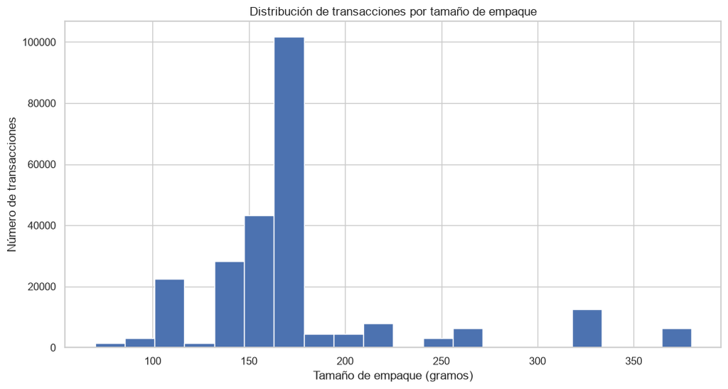

```python
# Histograma: cada barra representa un rango (bin) de tamaños de empaque
# y su altura indica cuántas transacciones caen en ese rango
transaction_data["PACK_SIZE"].hist(bins=20)

plt.xlabel("Tamaño de empaque (gramos)")
plt.ylabel("Número de transacciones")
plt.title("Distribución de transacciones por tamaño de empaque")
plt.show()
```

## 9. Crear la variable `BRAND`

La marca suele ser la primera palabra del nombre del producto.

```python
# .str.split() separa el nombre del producto en una lista de palabras
# .str[0] toma la primera palabra de cada lista (asumimos que ahí está la marca)
# .str.upper() estandariza todo a mayúsculas para evitar duplicados por casing
transaction_data["BRAND"] = (
    transaction_data["PROD_NAME"].str.split().str[0].str.upper()
)

# Revisamos las marcas resultantes y cuántas transacciones tiene cada una
transaction_data["BRAND"].value_counts()
```

```
BRAND
KETTLE        41288
SMITHS        27390
PRINGLES      25102
DORITOS       22041
THINS         14075
RRD           11894
INFUZIONS     11057
WW            10320
COBS           9693
TOSTITOS       9471
TWISTIES       9454
TYRRELLS       6442
GRAIN          6272
NATURAL        6050
CHEEZELS       4603
CCS            4551
RED            4427
DORITO         3183
INFZNS         3144
SMITH          2963
CHEETOS        2927
SNBTS          1576
BURGER         1564
WOOLWORTHS     1516
GRNWVES        1468
SUNBITES       1432
NCC            1419
FRENCH         1418
Name: count, dtype: int64
```

```python
# Diccionario de corrección: distintas abreviaciones/errores de tipeo que en
# realidad corresponden a la misma marca real (se identifican revisando la lista anterior)
brand_fix = {
    "RED": "RRD",          # "RED" es una abreviación de Red Rock Deli (RRD)
    "SNBTS": "SUNBITES",   # abreviación de Sunbites
    "INFZNS": "INFUZIONS", # abreviación de Infuzions
    "WW": "WOOLWORTHS",    # abreviación de Woolworths
    "SMITH": "SMITHS",     # variación singular/plural de Smiths
    "NCC": "NATURAL",      # abreviación de Natural Chip Co
    "DORITO": "DORITOS",   # variación singular/plural de Doritos
    "GRAIN": "GRNWVES",    # abreviación de Grain Waves
}

# .replace() sustituye cada marca mal escrita por su versión estandarizada,
# usando el diccionario anterior como mapa de reemplazo
transaction_data["BRAND"] = transaction_data["BRAND"].replace(brand_fix)

# Verificamos que las marcas quedaron consolidadas correctamente
transaction_data["BRAND"].value_counts()
```

```
BRAND
KETTLE        41288
SMITHS        30353
DORITOS       25224
PRINGLES      25102
RRD           16321
INFUZIONS     14201
THINS         14075
WOOLWORTHS    11836
COBS           9693
TOSTITOS       9471
TWISTIES       9454
GRNWVES        7740
NATURAL        7469
TYRRELLS       6442
CHEEZELS       4603
CCS            4551
SUNBITES       3008
CHEETOS        2927
BURGER         1564
FRENCH         1418
Name: count, dtype: int64
```

## 10. Explorar `customer_data`

```python
# .info() para ver tipos de dato y nulos en el dataset de clientes
customer_data.info()
```

```
<class 'pandas.DataFrame'>
RangeIndex: 72637 entries, 0 to 72636
Data columns (total 3 columns):
 #   Column            Non-Null Count  Dtype
---  ------            --------------  -----
 0   LYLTY_CARD_NBR    72637 non-null  int64
 1   LIFESTAGE         72637 non-null  str
 2   PREMIUM_CUSTOMER  72637 non-null  str
dtypes: int64(1), str(2)
memory usage: 1.7 MB
```

```python
# .describe(include="all") incluye también columnas de texto/categóricas,
# mostrando frecuencias de las categorías más comunes (LIFESTAGE, PREMIUM_CUSTOMER)
customer_data.describe(include="all")
```

|  | LYLTY_CARD_NBR | LIFESTAGE | PREMIUM_CUSTOMER |
| --- | --- | --- | --- |
| count | 7.263700e+04 | 72637 | 72637 |
| unique | NaN | 7 | 3 |
| top | NaN | RETIREES | Mainstream |
| freq | NaN | 14805 | 29245 |
| mean | 1.361859e+05 | NaN | NaN |
| std | 8.989293e+04 | NaN | NaN |
| min | 1.000000e+03 | NaN | NaN |
| 25% | 6.620200e+04 | NaN | NaN |
| 50% | 1.340400e+05 | NaN | NaN |
| 75% | 2.033750e+05 | NaN | NaN |
| max | 2.373711e+06 | NaN | NaN |

## 11. Unir (merge) transacciones con datos de cliente

```python
# merge() combina ambos DataFrames usando la columna en común "LYLTY_CARD_NBR"
# how="left" mantiene TODAS las filas de transaction_data, y les agrega la
# información de customer_data cuando encuentra una coincidencia
data = transaction_data.merge(customer_data, on="LYLTY_CARD_NBR", how="left")

# assert lanza un error si la condición es falsa: confirmamos que el merge NO
# generó filas adicionales (lo cual indicaría duplicados en customer_data)
assert len(data) == len(transaction_data), "El merge generó duplicados inesperados"

# Si no hay error, mostramos las dimensiones finales del dataset combinado
data.shape
```

```
(246740, 12)
```

```python
# Revisamos si alguna transacción quedó sin datos de cliente después del merge
# (es decir, si hay algún LIFESTAGE o PREMIUM_CUSTOMER nulo)
data[["LIFESTAGE", "PREMIUM_CUSTOMER"]].isna().sum()

# Si el resultado es 0 en ambas columnas, todos los clientes fueron encontrados
```

```
LIFESTAGE           0
PREMIUM_CUSTOMER    0
dtype: int64
```

```python
# Guardamos el dataset limpio y combinado en un nuevo archivo CSV,
# útil como punto de partida para el Task 2 del internship
data.to_csv(file_path + "QVI_data.csv", index=False)
```

## 12. Análisis por segmento de cliente (`LIFESTAGE` x `PREMIUM_CUSTOMER`)

Ahora calculamos las métricas clave para entender qué segmentos impulsan más las ventas de chips.

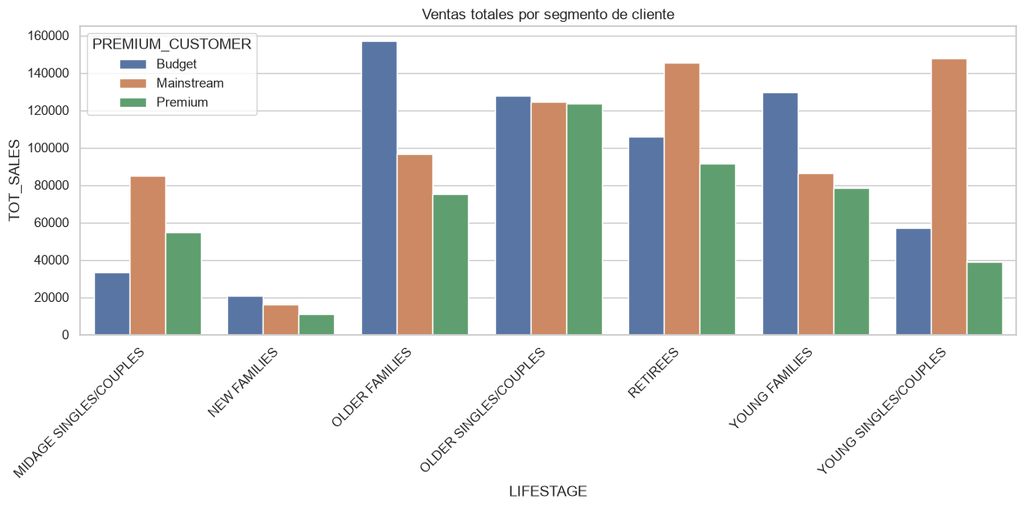

```python
# Agrupamos por las dos dimensiones de segmentación y sumamos TOT_SALES
# (ventas totales) dentro de cada combinación de grupo
sales_by_segment = (
    data.groupby(["LIFESTAGE", "PREMIUM_CUSTOMER"])["TOT_SALES"]
    .sum()                          # suma las ventas dentro de cada grupo
    .reset_index()                  # convierte el resultado agrupado en DataFrame plano
)

# Gráfico de barras agrupadas: eje X = etapa de vida, color = tipo de comprador,
# altura de barra = ventas totales
plt.figure(figsize=(12, 6))
sns.barplot(data=sales_by_segment, x="LIFESTAGE", y="TOT_SALES", hue="PREMIUM_CUSTOMER")

plt.xticks(rotation=45, ha="right")   # rota etiquetas para que no se sobrepongan
plt.title("Ventas totales por segmento de cliente")
plt.tight_layout()
plt.show()
```

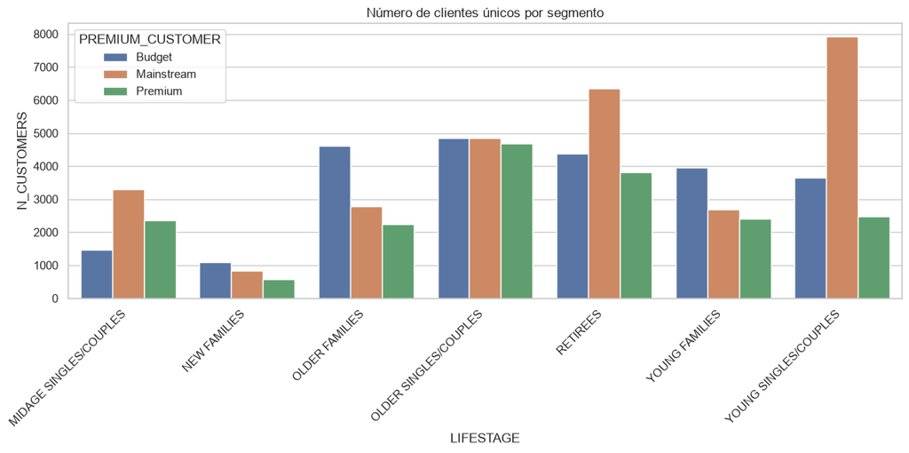

```python
# nunique() cuenta cuántas tarjetas de lealtad DISTINTAS hay en cada grupo,
# es decir, cuántos clientes únicos compran en cada segmento
customers_by_segment = (
    data.groupby(["LIFESTAGE", "PREMIUM_CUSTOMER"])["LYLTY_CARD_NBR"]
    .nunique()
    .reset_index(name="N_CUSTOMERS")
)

plt.figure(figsize=(12, 6))
sns.barplot(data=customers_by_segment, x="LIFESTAGE", y="N_CUSTOMERS", hue="PREMIUM_CUSTOMER")
plt.xticks(rotation=45, ha="right")
plt.title("Número de clientes únicos por segmento")
plt.tight_layout()
plt.show()
```

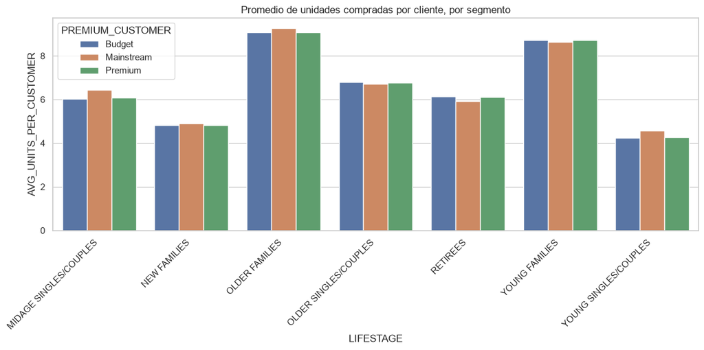

```python
# Función auxiliar: para cada grupo, suma la cantidad total de productos comprados
# (PROD_QTY) y la divide entre el número de clientes únicos del grupo
def avg_units_per_customer(group):
    total_units = group["PROD_QTY"].sum()               # unidades totales del grupo
    unique_customers = group["LYLTY_CARD_NBR"].nunique() # clientes únicos del grupo
    return total_units / unique_customers                # promedio de unidades por cliente

# .apply() ejecuta la función anterior sobre cada grupo definido por groupby()
units_per_customer = (
    data.groupby(["LIFESTAGE", "PREMIUM_CUSTOMER"])
    .apply(avg_units_per_customer)
    .reset_index(name="AVG_UNITS_PER_CUSTOMER")
)

plt.figure(figsize=(12, 6))
sns.barplot(data=units_per_customer, x="LIFESTAGE", y="AVG_UNITS_PER_CUSTOMER", hue="PREMIUM_CUSTOMER")
plt.xticks(rotation=45, ha="right")
plt.title("Promedio de unidades compradas por cliente, por segmento")
plt.tight_layout()
plt.show()
```

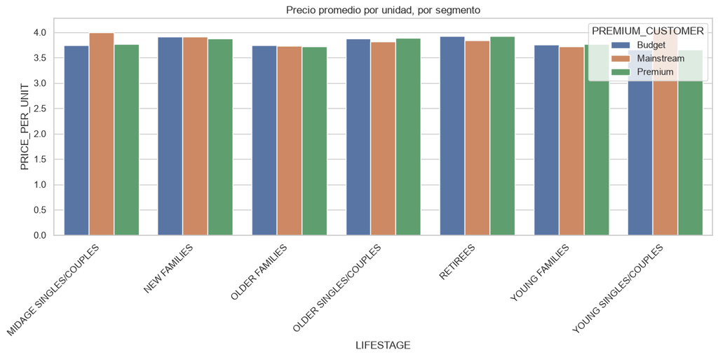

```python
# Calculamos el precio pagado por unidad en cada transacción:
# ventas totales de la transacción / cantidad de unidades compradas
data["PRICE_PER_UNIT"] = data["TOT_SALES"] / data["PROD_QTY"]

# Promediamos ese precio por unidad dentro de cada segmento de cliente
avg_price = (
    data.groupby(["LIFESTAGE", "PREMIUM_CUSTOMER"])["PRICE_PER_UNIT"]
    .mean()
    .reset_index()
)

plt.figure(figsize=(12, 6))
sns.barplot(data=avg_price, x="LIFESTAGE", y="PRICE_PER_UNIT", hue="PREMIUM_CUSTOMER")
plt.xticks(rotation=45, ha="right")
plt.title("Precio promedio por unidad, por segmento")
plt.tight_layout()
plt.show()
```

## 13. Prueba de hipótesis (t-test)

Comparamos el precio por unidad pagado por clientes **Mainstream** (jóvenes y de mediana edad, solteros/parejas) contra el pagado por clientes **Budget** y **Premium** del mismo grupo etario, para confirmar si la diferencia observada en el gráfico anterior es estadísticamente significativa.

```python
# Filtramos las filas del grupo "Mainstream" dentro de las etapas de vida
# jóvenes/mediana edad solteros o en pareja
mainstream_mask = (
    (data["PREMIUM_CUSTOMER"] == "Mainstream") &
    (data["LIFESTAGE"].isin(["YOUNG SINGLES/COUPLES", "MIDAGE SINGLES/COUPLES"]))
)
mainstream_prices = data.loc[mainstream_mask, "PRICE_PER_UNIT"]

# Filtramos las filas de "Budget" o "Premium" dentro de las mismas etapas de vida,
# para comparar contra el grupo Mainstream
other_mask = (
    (data["PREMIUM_CUSTOMER"].isin(["Budget", "Premium"])) &
    (data["LIFESTAGE"].isin(["YOUNG SINGLES/COUPLES", "MIDAGE SINGLES/COUPLES"]))
)
other_prices = data.loc[other_mask, "PRICE_PER_UNIT"]

# ttest_ind realiza una prueba t de dos muestras independientes
# equal_var=False usa la corrección de Welch (no asume varianzas iguales entre grupos)
t_stat, p_value = stats.ttest_ind(mainstream_prices, other_prices, equal_var=False)

# Mostramos el estadístico t y el p-value resultante
print(f"Estadístico t: {t_stat:.4f}")
print(f"p-value: {p_value:.6f}")

# Si p_value < 0.05, la diferencia de precios es estadísticamente significativa
if p_value < 0.05:
    print("La diferencia de precio por unidad SÍ es estadísticamente significativa.")
else:
    print("La diferencia de precio por unidad NO es estadísticamente significativa.")
```

```
Estadístico t: 37.6244
p-value: 0.000000
La diferencia de precio por unidad SÍ es estadísticamente significativa.
```

## 14. Deep dive: afinidad de marca y tamaño de empaque

Analizamos en detalle el segmento **Mainstream - Young Singles/Couples** (uno de los que más contribuye a las ventas) para ver si prefiere marcas o tamaños de empaque particulares, comparado con el resto de la población.

```python
# Filtramos el segmento objetivo: Mainstream + jóvenes solteros/parejas
target_mask = (
    (data["LIFESTAGE"] == "YOUNG SINGLES/COUPLES") &
    (data["PREMIUM_CUSTOMER"] == "Mainstream")
)
target = data[target_mask]

# El resto de la población es todo lo que NO está en el segmento objetivo
rest = data[~target_mask]

# .value_counts(normalize=True) da la PROPORCIÓN (no el conteo) de cada marca
# dentro del segmento objetivo, para poder comparar en igualdad de condiciones
target_brand_share = target["BRAND"].value_counts(normalize=True)

# Lo mismo pero calculado sobre el resto de la población
rest_brand_share = rest["BRAND"].value_counts(normalize=True)

# El índice de afinidad es la razón entre ambas proporciones:
# > 1 significa que la marca está sobre-representada en el segmento objetivo
# < 1 significa que está sub-representada
affinity_brand = (target_brand_share / rest_brand_share).sort_values(ascending=False)

# Mostramos las 10 marcas con mayor afinidad hacia el segmento objetivo
affinity_brand.head(10)
```

```
BRAND
TYRRELLS     1.235751
TWISTIES     1.223096
DORITOS      1.210572
TOSTITOS     1.205700
KETTLE       1.193406
PRINGLES     1.181003
COBS         1.137600
INFUZIONS    1.122003
GRNWVES      1.058592
THINS        1.050009
Name: proportion, dtype: float64
```

```python
# Repetimos el mismo cálculo de afinidad, pero ahora para PACK_SIZE en vez de BRAND
target_pack_share = target["PACK_SIZE"].value_counts(normalize=True)
rest_pack_share = rest["PACK_SIZE"].value_counts(normalize=True)

affinity_pack = (target_pack_share / rest_pack_share).sort_values(ascending=False)

# Tamaños de empaque con mayor afinidad hacia el segmento objetivo
affinity_pack.head(10)
```

```
PACK_SIZE
270    1.272269
380    1.256849
330    1.224477
134    1.181003
210    1.175546
110    1.172431
135    1.136234
250    1.126673
170    0.994629
150    0.964484
Name: proportion, dtype: float64
```

Con esto queda completo el EDA equivalente al template en R, listo para pasar al Task 2 (recomendaciones de estrategia comercial).

## 15. Conclusiones

**Segmento objetivo:** Mainstream – Young Singles/Couples

### Marca preferida

| Marca | Índice de afinidad |
| --- | --- |
| Tyrrells | 1.24x |
| Twisties | 1.22x |
| Doritos | 1.21x |
| Tostitos | 1.21x |
| Kettle | 1.19x |
| Pringles | 1.18x |
| Cobs | 1.14x |
| Infuzions | 1.12x |
| Grain Waves | 1.06x |
| Thins | 1.05x |

### Tamaño de empaque preferido

| Tamaño (g) | Índice de afinidad |
| --- | --- |
| 270 | 1.27x |
| 380 | 1.26x |
| 330 | 1.22x |
| 134 | 1.18x |
| 210 | 1.18x |
| 110 | 1.17x |
| 135 | 1.14x |
| 250 | 1.13x |
| 170 | 0.99x |
| 150 | 0.96x |

**Lectura de negocio:** preferencia clara por empaques **grandes** (270g–380g), contrario a lo que se esperaría de "jóvenes solteros/parejas" comprando porciones individuales. Los tamaños estándar (150g, 170g) están en o por debajo del promedio del resto de la población. Sugiere consumo para compartir o para varios días, no snacking individual de paso.

### Precio por unidad

- **t = 37.6244, p < 0.000001** → diferencia estadísticamente significativa (muy por debajo del umbral α = 0.05).
- El signo positivo del estadístico t confirma que el segmento **Mainstream paga más por unidad** que Budget/Premium dentro del mismo grupo etario (Young/Midage Singles & Couples).

**Lectura de negocio:** este segmento no es sensible al precio en la misma medida que Budget — está dispuesto a pagar un premium por unidad, lo cual es consistente con su preferencia por marcas premium/especializadas (Tyrrells, Kettle) y formatos grandes.

### Recomendación estratégica para Julia

El segmento **Mainstream – Young Singles/Couples** es un objetivo de alto valor para la categoría:

1. **Producto:** priorizar Tyrrells, Twisties, Doritos, Tostitos y Kettle en el surtido asignado a este segmento, y en la ubicación destacada de anaquel.
2. **Formato:** enfocar el mix hacia empaques grandes (270g-380g) en lugar de individuales — este segmento compra para compartir/consumo prolongado, no snack de paso.
3. **Precio:** dado que pagan significativamente más por unidad y sin evidencia de alta sensibilidad al precio, hay margen para mantener o incluso testear precios premium en estas combinaciones marca-tamaño sin necesidad de descuentos agresivos, a diferencia de lo que se recomendaría para el segmento Budget.
4. **Próximo paso sugerido:** cruzar marca × tamaño de forma conjunta (no por separado) para aislar si la afinidad de tamaño viene del tamaño en sí o está arrastrada por la marca que lo distribuye (ej. Pringles en 134g).

Con esto queda cerrado el EDA equivalente al template en R, listo para pasar al Task 2 (recomendaciones de estrategia comercial y presentación a Julia).